# Question 1.

On charge en mémoire les données et on en donne un aperçu:

```r
setwd("C://Users//etudiant//Downloads" )


x <- read.table("climats.txt", sep = ";",
                header = TRUE, row.names = 1)
# View(x)
head(x) # pour afficher les six premières colonnes
```

```
##             January February March April  May June July August September
## Amsterdam       2.9      2.5   5.7   8.2 12.5 14.8 17.1   17.1      14.5
## Athens          9.1      9.7  11.7  15.4 20.1 24.5 27.4   27.2      23.8
## Berlin         -0.2      0.1   4.4   8.2 13.8 16.0 18.3   18.0      14.4
## Brussels        3.3      3.3   6.7   8.9 12.8 15.6 17.8   17.8      15.0
## Budapest       -1.1      0.8   5.5  11.6 17.0 20.2 22.0   21.3      16.9
## Copenhagen     -0.4     -0.4   1.3   5.8 11.1 15.4 17.1   16.6      13.3
##             October November December Annual Amplitude Latitude Longitude  Area
## Amsterdam      11.4      7.0      4.4    9.9      14.6     52.2       4.5  West
## Athens         19.2     14.6     11.0   17.8      18.3     37.6      23.5 South
## Berlin         10.0      4.2      1.2    9.1      18.5     52.3      13.2  West
## Brussels       11.1      6.7      4.4   10.3      14.4     50.5       4.2  West
## Budapest       11.3      5.1      0.7   10.9      23.1     47.3      19.0  East
## Copenhagen      8.8      4.1      1.3    7.8      17.5     55.4      12.3 North
```

# Question 2.

```r
dim(x)
```

```
## [1] 35 17
```

```r
str(x)
```

```
## 'data.frame':    35 obs. of  17 variables:
##  $ January  : num  2.9 9.1 -0.2 3.3 -1.1 -0.4 4.8 -5.8 -5.9 -3.7 ...
##  $ February : num  2.5 9.7 0.1 3.3 0.8 -0.4 5 -6.2 -5 -2 ...
##  $ March    : num  5.7 11.7 4.4 6.7 5.5 1.3 5.9 -2.7 -0.3 1.9 ...
##  $ April    : num  8.2 15.4 8.2 8.9 11.6 5.8 7.8 3.1 7.4 7.9 ...
##  $ May      : num  12.5 20.1 13.8 12.8 17 11.1 10.4 10.2 14.3 13.2 ...
##  $ June     : num  14.8 24.5 16 15.6 20.2 15.4 13.3 14 17.8 16.9 ...
##  $ July     : num  17.1 27.4 18.3 17.8 22 17.1 15 17.2 19.4 18.4 ...
##  $ August   : num  17.1 27.2 18 17.8 21.3 16.6 14.6 14.9 18.5 17.6 ...
##  $ September: num  14.5 23.8 14.4 15 16.9 13.3 12.7 9.7 13.7 13.7 ...
##  $ October  : num  11.4 19.2 10 11.1 11.3 8.8 9.7 5.2 7.5 8.6 ...
##  $ November : num  7 14.6 4.2 6.7 5.1 4.1 6.7 0.1 1.2 2.6 ...
##  $ December : num  4.4 11 1.2 4.4 0.7 1.3 5.4 -2.3 -3.6 -1.7 ...
##  $ Annual   : num  9.9 17.8 9.1 10.3 10.9 7.8 9.3 4.8 7.1 7.7 ...
##  $ Amplitude: num  14.6 18.3 18.5 14.4 23.1 17.5 10.2 23.4 25.3 22.1 ...
##  $ Latitude : num  52.2 37.6 52.3 50.5 47.3 55.4 53.2 60.1 50.3 50 ...
##  $ Longitude: num  4.5 23.5 13.2 4.2 19 12.3 6.1 25 30.3 19.6 ...
##  $ Area     : chr  "West" "South" "West" "West" ...
```

Il y a $p=12$ variables quantitatives primaires, chacune correspondante à une temperature mensuelle moyenne. L’espace des individus est donc $\mathbb{R}^{12}$. Chaque individu correspond à une ville européene. Au total, il y a $n=35$ villes.

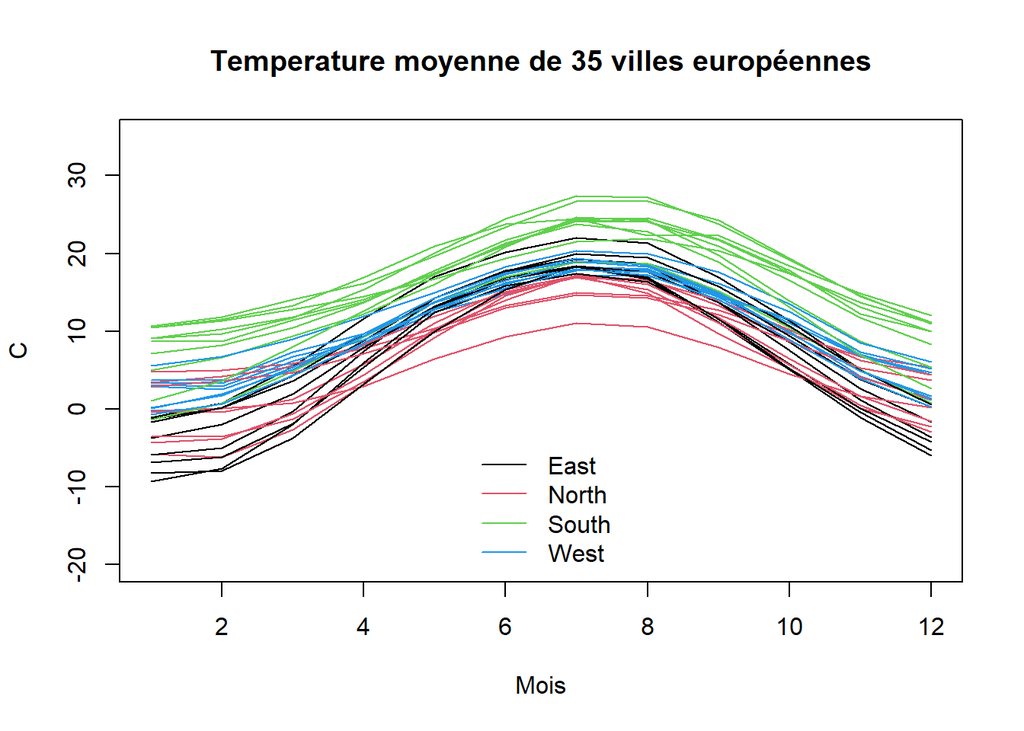

```r
plot(as.numeric(x[1,1:12]), type = 'l',
     col = as.factor(x$Area)[1], ylim = c(-20,35),
     ylab = "C", xlab = "Mois",
     main = "Temperature moyenne de 35 villes européennes")
for(i in 2:nrow(x)) points(as.numeric(x[i,1:12]),type='l',col=as.factor(x$Area)[i])
legend(x = 'bottom', lty = 1,
       col = 1:4, legend = c("East", "North", "South", "West"),
       bty = 'n')
```

# Question 3.

# Introduction

Ce document analyse les températures mensuelles moyennes de 35 grandes villes européennes. L’objectif est d’explorer les données, d’appliquer des méthodes statistiques avancées comme l’ACP (Analyse en Composantes Principales) et la CAH (Classification Ascendante Hiérarchique), et d’interpréter les résultats pour en tirer des insights.

```r
 setwd("C://Users//etudiant//Downloads")

 x<-read.table("climats.txt",sep=";",header=TRUE,row.names=1)
 View(x)
 head(x) #pourafficherlessixpremièrescolonnes
```

```
##             January February March April  May June July August September
## Amsterdam       2.9      2.5   5.7   8.2 12.5 14.8 17.1   17.1      14.5
## Athens          9.1      9.7  11.7  15.4 20.1 24.5 27.4   27.2      23.8
## Berlin         -0.2      0.1   4.4   8.2 13.8 16.0 18.3   18.0      14.4
## Brussels        3.3      3.3   6.7   8.9 12.8 15.6 17.8   17.8      15.0
## Budapest       -1.1      0.8   5.5  11.6 17.0 20.2 22.0   21.3      16.9
## Copenhagen     -0.4     -0.4   1.3   5.8 11.1 15.4 17.1   16.6      13.3
##             October November December Annual Amplitude Latitude Longitude  Area
## Amsterdam      11.4      7.0      4.4    9.9      14.6     52.2       4.5  West
## Athens         19.2     14.6     11.0   17.8      18.3     37.6      23.5 South
## Berlin         10.0      4.2      1.2    9.1      18.5     52.3      13.2  West
## Brussels       11.1      6.7      4.4   10.3      14.4     50.5       4.2  West
## Budapest       11.3      5.1      0.7   10.9      23.1     47.3      19.0  East
## Copenhagen      8.8      4.1      1.3    7.8      17.5     55.4      12.3 North
```

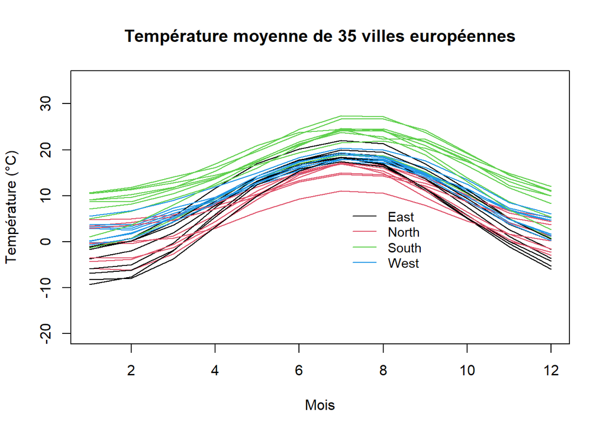

```r
# Tracer le graphique des températures moyennes des villes européennes
# Initialiser le graphique avec la première courbe
plot(as.numeric(x[1, 1:12]), type = 'l',
     col = as.factor(x$Area)[1], ylim = c(-20, 35),
     ylab = "Température (°C)", xlab = "Mois",
     main = "Température moyenne de 35 villes européennes")

# Ajouter les courbes pour les autres villes
for (i in 2:nrow(x)) {
  points(as.numeric(x[i, 1:12]), type = 'l', col = as.factor(x$Area)[i])
}

# Ajouter une légende complète avec position personnalisée
legend(x = 7, y = 9, lty = 1,
       col = 1:4, legend = c("East", "North", "South", "West"),
       bty = 'n', cex = 0.9)
```

```r
 #3Calculer la moyenne et l’écart type de chaque variable. Calculer la variance du nuage de points dans
#l’espace des individus.
n <- nrow(x)  # Nombre d'individus

# Moyenne
m <- apply(x[, 1:12], 2, mean)
print(m)
```

```
##   January  February     March     April       May      June      July    August
##  1.345714  2.217143  5.228571  9.282857 13.911429 17.414286 19.622857 18.980000
## September   October  November  December
## 15.631429 11.002857  6.065714  2.880000
```

```r
#variance
var<-apply(x[, 1:12], 2, var) # Par défaut, divise par n-1
# Ajuster pour diviser par n
variances_adjusted <- var* (n-1) / n
print(variances_adjusted)
```

```
##   January  February     March     April       May      June      July    August
##  29.40877  29.37456  22.97347  14.07513  10.41016  10.70922  12.41319  13.50046
## September   October  November  December
##  16.40730  18.15628  20.25997  23.97017
```

```r
#écart-type
sigma<-sqrt(variances_adjusted)
print(sigma)
```

```
##   January  February     March     April       May      June      July    August
##  5.422985  5.419831  4.793065  3.751684  3.226477  3.272495  3.523236  3.674297
## September   October  November  December
##  4.050592  4.261018  4.501107  4.895934
```

```r
# Variance totale du nuage de points
variance_totale <- sum(variances_adjusted)
print(variance_totale)
```

```
## [1] 221.6587
```

```r
# Rappel: var calcule la variance en divisant par n-1,
# en multipliant par (n-1)/n on se ramène à la définition
# de variance vue en cours.
```

4. Pour chaque région géographique (variable supplémentaire Area) calculer la température moyenne de chaque mois, la variance de chaque mois, et la variance totale du sous-nuage de points.

```r
x_w <- x[x$Area == "West",1:12]
n_w <- nrow(x_w)
m_w <- apply(x_w, 2, mean); m_w
apply(x_w, 2, var) * (n_w-1) / n_w
v_w <- sum(apply(x_w, 2, var) * (n_w-1)/ n_w); v_w
# sum(apply(x_w, 2, var))

x_e <- x[x$Area == "East",1:12]
n_e <- nrow(x_e)
m_e <- apply(x_e, 2, mean); m_e
apply(x_e, 2, var) * (n_e-1)/ n_e
v_e <- sum(apply(x_e, 2, var) * (n_e-1)/ n_e); v_e
sum(apply(x_e, 2, var))

x_s <- x[x$Area == "South",1:12]
n_s <- nrow(x_s)
m_s <- apply(x_s, 2, mean); m_s
apply(x_s, 2, var) * (n_s-1)/ n_s
v_s <- sum(apply(x_s, 2, var) * (n_s-1)/ n_s); v_s

x_n <- x[x$Area == "North",1:12]
n_n <- nrow(x_n)
m_n <- apply(x_n, 2, mean); m_n
apply(x_n, 2, var) * (n_n-1)/ n_n
v_n <- sum(apply(x_n, 2, var) * (n_n-1)/ n_n); v_n

# library(dplyr)
# x %>% group_by(Area) %>% summarise(across(1:12, ~ mean(.x)))
```

[output not shown]

??pca #. Réaliser une ACP. Pour cela: # choisir entre ACP simple ou standard; #• réaliser l’ACP; #choisir le nombre d’axe à retenir; #• afficher graphiquement la projection des individus sur le plan principal; # afficher le “cercle de corrélation”; #• interpréter les axes principaux retenus à l’aide des contributions des #ariables et des individus les #mieux représentés. Penser à bien décrire et justifier les démarches adoptées

```r
install.packages("FactoMineR")
library(FactoMineR)
# On fait une ACP standard, même si les variances ne sont pas
# très différentes
x$cl3 <- as.factor(x$cl3)
x <- na.omit(x)
str(x)
x <- x[, !names(x) %in% "cl3"]
acp <- PCA(x, scale.unit = TRUE, quali.sup = 17, quanti.sup = 13:16)
```

[output not shown]